# Kuis Komputasi Statistik Intensif

## Nama: Yenro P. Sagala

## NRP: 6003232003

```python
import numpy as np
import matplotlib.pyplot as plt
import pandas as pd
from scipy.stats import norm, halfnorm
import statsmodels.api as sm
import warnings
import seaborn as sns
from scipy.optimize import minimize


warnings.filterwarnings('ignore')
```

## Generate Data

```python
length = 100
x = np.random.rand(length)
e = np.random.randn(length)
y = e * x
df = pd.DataFrame(list(zip(x,y)), columns=['x','y'])
n = len(df)
```

### Deskripsi Data

Data yang digunakan pada percobaan ini merupakan data hasil generate dengan sebaran data dapat tunjukkan sebagai berikut:

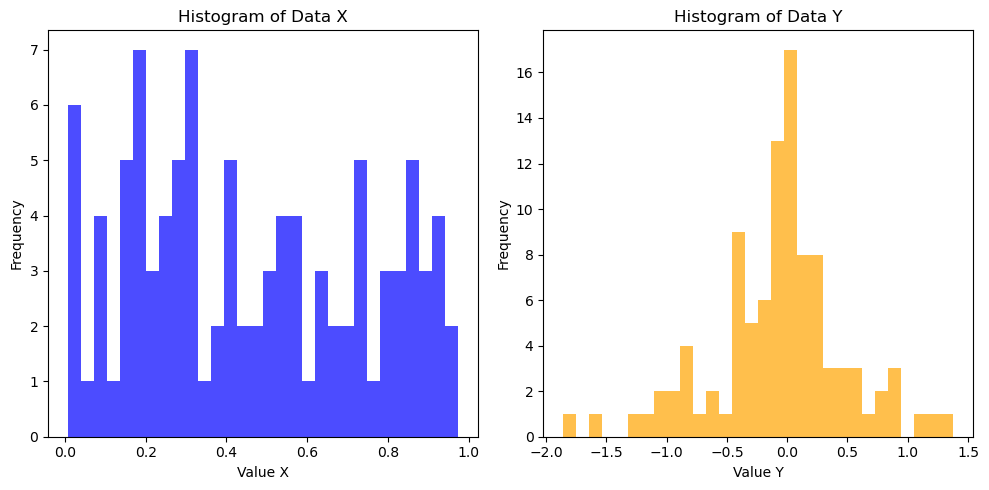

```python
fig, axs = plt.subplots(nrows=1, ncols=2, figsize=(10, 5))

axs[0].hist(df.x, bins=30, color='blue', alpha=0.7)
axs[0].set_title('Histogram of Data X')
axs[0].set_xlabel('Value X')
axs[0].set_ylabel('Frequency')

axs[1].hist(df.y, bins=30, color='orange', alpha=0.7)
axs[1].set_title('Histogram of Data Y')
axs[1].set_xlabel('Value Y')
axs[1].set_ylabel('Frequency')

# Adjust spacing between subplots
plt.tight_layout()

# Show the plot
plt.show()
```

### Fungsi membangkitkan nilai parameter

Para prosedur accept-reject dengan tiga parameter seperti pada contoh ini adalah regresi linear berganda dengan parameter b0, b1, dan sigma, diperlukan prosedur estimasi nilai parameter yang memaksimumkan nilai log_likelihood, namun proses ini tidak dilakukan secara langsung, melainkan dengan menggunakan markov-chain. pada masing-masing fungsi genereta parameter, diberikan input nilai bagi parameter lain serta nilai data X dan Y, maka dengan funsi ini akan memperoleh nilai parameter yang memberikan nilai log_likelihood terbesar ketika parameter lain dan data telah diketahui. Hasil dari masing-masing parameter yang digenerate kemudian disimpan pada list yang bersesuaian.

```python
from scipy.optimize import minimize

def log_likelihood(b0, b1, sigma):
    lnL = (-(float(n)*0.5) * np.log(2.0 * np.pi * (float(sigma)**2.0))) - (0.5 * np.sum((y - float(b0) - float(b1)*x)/float(sigma))**2.0)
    return - lnL


# Method = 'NM'     # "Nelder-Mead"
# Method = 'BFGS'   # "Broyden-Fletcher-Goldfarb-Shanno"
# Method = 'CG'     # "Conjugate-gradient"
Method = 'SLSQP'    # "Sequential Least SQuares Programming"

def gen_b0():
    b0 = [b0s[-1]] #initial value dari componen terakhir list b0s
    b1 = b1s[-1]  #last value parameter b1
    sigma = sigmas[-1] #last value parameter sigma
    Results = minimize(log_likelihood,
                           b0,
                           method=Method,args=(b1, sigma),
                           options={'xatol': 1e-8, 'disp': False}
                           )
    b0s.append(Results.x[0])
    return Results.x[0]

def gen_b1():
    b1 = [b1s[-1]] #initial value dari componen terakhir list b1s
    b0 = b0s[-1]  #last value parameter b0
    sigma = sigmas[-1]  #last value parameter sigma
    Results = minimize(log_likelihood,
                           b1,
                           method=Method,args=(b0, sigma),
                           options={'xatol': 1e-8, 'disp': False}
                           )
    b1s.append(Results.x[0])
    return Results.x[0]

def gen_sigma():
    sigma0 = [sigmas[-1]]  #initial value dari componen terakhir list sigmas
    b1 = b1s[-1] #last value parameter b1
    b0 = b0s[-1]  #last value parameter b0
    Results = minimize(log_likelihood,
                           sigma0,
                           method=Method,args=(b0, b1),
                           options={'xatol': 1e-8, 'disp': False}
                           )
    sigmas.append(Results.x[0])
    return Results.x[0]
```

### Fungsi menghitung Densitas maksimum ketika given parameter

Berbeda dengan fungsi sebelumnya, fungi ini berupaya memaksimumkan nilai densitas dimana parameter telah diberikan dengan dengan melakukan iterasi pada masing-masing data set x dan y. adapun return dari fungsi ini adalah nilai maksimum dari log_likelood dari data given parameter.

```python
def max_dens(data, b0, b1, sigma):
    log_likelihood = (-(float(n)*0.5) * np.log(2.0 * np.pi * (float(sigma)**2.0))) - (0.5 * np.sum((y - float(b0) - float(b1)*x)/float(sigma))**2.0)
    return -log_likelihood

def max():
    df0 = np.array(df.iloc[0])
    b1 = b1s[-1] #given parameter
    b0 = b0s[-1] #given parameter
    sigma = sigmas[-1] #given parameter
    result = minimize(max_dens,
                      df0,
                      method='SLSQP',  # Replace with your desired method
                      args=(b1,b0,sigma),
                      options={'xatol': 1e-8, 'disp': False}
                      )
    return result.fun
```

### Fungsi Accept Reject Sampling

Parameter yang digenerate diterima sebagai bagian dari sampling jika nilai dari nilai likelihood dibandingkan dengan likelihood maksimum lebih besar dari angka random yang digenerate dari distribusi normal standar (0,1).

```python
def accept():

    a = gen_b0()
    b = gen_b1()
    c = gen_sigma()

    u = np.random.normal(0, 1)
    value = log_likelihood(a,b,c) / max()
    if u < value:
        return {'b0': a , 'b1': b, 'sigma': c}
```

### Fungsi Iterasi

Percobaan ini diulang sebanyak n iterasi, dimana setiap iterasi yang memperoleh parameter yang diterima, disimpan dalam array result. sedangkan parameter yang tidak diterima tidak disimpan. masing-masing parameter disimpan dalam sebuah list dimana data pertama dalam list merupakan initial guess untuk melakukan generate parameter.

```python
from tqdm import tqdm
b0s = [0.1]
b1s = [0.1]
sigmas = [0.1]

results = []
for i in tqdm(range(50)):
    result = accept()
    if result:
        results.append(result)

result = pd.DataFrame(results)
```

Kemudian hasil dari percobaan tersebut dapat di deskripsikan sebagai berikut:

```python
result.describe()
```

|  | b0 | b1 | sigma |
| --- | --- | --- | --- |
| count | 39.000000 | 39.000000 | 39.000000 |
| mean | -0.045361 | -0.045223 | -0.045223 |
| std | 0.000492 | 0.000227 | 0.000227 |
| min | -0.048286 | -0.045266 | -0.045266 |
| 25% | -0.045266 | -0.045266 | -0.045266 |
| 50% | -0.045266 | -0.045266 | -0.045266 |
| 75% | -0.045266 | -0.045266 | -0.045266 |
| max | -0.045266 | -0.043875 | -0.043875 |

Berdasarkan hasil iterasi diatas didapati bahwa hanya 39 dari 50 percobaan yang memenuhi kriteria sebagai sample.

### Plot iterasi nilai parameter

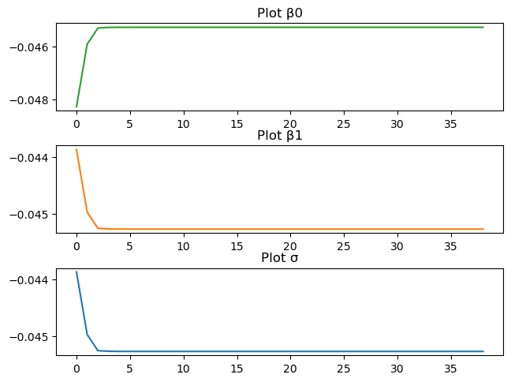

```python
fig, axs = plt.subplots(3,1)
fig.tight_layout()
axs[0].plot(result.b0, 'tab:green')
axs[0].set_title('Plot β0')
axs[1].plot(result.b1, 'tab:orange')
axs[1].set_title('Plot β1')
axs[2].plot(result.sigma, 'tab:blue')
axs[2].set_title('Plot σ')
plt.show()
```

Berdasarkan plot diatas, untuk khasus ini, didapatai bahwa nilai masing-masing parameter yang diestimasi cukup cepat mencapai titik konvergen dimana pada iterasi iterasi dibawah 5 iterasi.

### Plot sebaran nilai parameter

Hasil percobaan jika plotkan antara iterasi dengan nilai parameter, dapat dilihat bahwa masing-masing parameter sudah konvergen. hal ini terlihat dari nilai masing-masing parameter yang menyebar pada titik tengah masing-masing parameter.

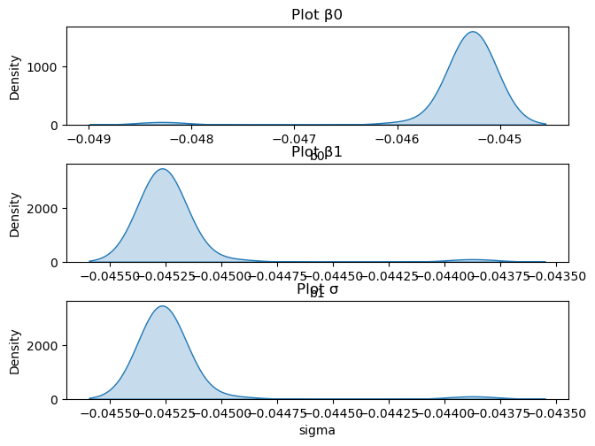

```python
fig, axs = plt.subplots(3,1)
fig.tight_layout()
sns.kdeplot(result.b0, ax = axs[0], fill=True)
sns.kdeplot(result.b1, ax = axs[1], fill=True)
sns.kdeplot(result.sigma, ax = axs[2], fill=True)
axs[2].set_title('Plot σ')
axs[1].set_title('Plot β1')
axs[0].set_title('Plot β0')
plt.show()
```